# Analyses of the manuscript: Machine Learning Does not Outperform Logistic Regression in the Prediction of Sexual Relapse in a Sample of Individuals Convicted of Sexual Offenses

Florian Pargent & Felix Schönbrodt

2022-04-06

The target variable for all analyses is *RF_Sex_FIX_5*. The absolute and relative frequencies are:

```
##
##   0   1
## 464  47
```

```
##
##     0     1
## 0.908 0.092
```

# Descriptive Statistics

|  | Alter_Entlassung.min | Alter_Entlassung.max | Alter_Entlassung.mean | Alter_Entlassung.sd | Kontrolle_Haftdauer_in_Tagen.min | Kontrolle_Haftdauer_in_Tagen.max | Kontrolle_Haftdauer_in_Tagen.mean | Kontrolle_Haftdauer_in_Tagen.sd |
| --- | --- | --- | --- | --- | --- | --- | --- | --- |
| 1 | 16.1342465753425 | 71.8438356164384 | 41.7837492963032 | 12.910275056027 | 21 | 7162 | 973.430528375733 | 912.147269761225 |

# Correlations between predictor variables

```
##                  rowid             colid     value
## 1223 STATIC_Kat_recalc STATIC_Sum_recalc 0.9569299
## 1258 STATIC_Sum_recalc STATIC_Kat_recalc 0.9569299
## 1260 StaSta_Kat_recalc STATIC_Kat_recalc 0.8914455
## 1295 STATIC_Kat_recalc StaSta_Kat_recalc 0.8914455
## 152       vordelsexoff         vordelsex 0.8666249
## 257          vordelsex      vordelsexoff 0.8666249
## 1224 StaSta_Kat_recalc STATIC_Sum_recalc 0.8585474
## 1294 STATIC_Sum_recalc StaSta_Kat_recalc 0.8585474
## 779         Stable_Kat        Stable_Sum 0.8391193
## 814         Stable_Sum        Stable_Kat 0.8391193
## 76           vordelgew         vordelges 0.7524406
## 111          vordelges         vordelgew 0.7524406
## 168    Static99_Item_5         vordelsex 0.7110712
## 833          vordelsex   Static99_Item_5 0.7110712
## 97     Static99_Item_2         vordelges 0.7024338
## 867          vordelges   Static99_Item_2 0.7024338
## 892    Static99_Item_1   Static99_Item_2 0.6622424
## 997    Static99_Item_2   Static99_Item_1 0.6622424
## 862  STATIC_Sum_recalc   Static99_Item_5 0.6063122
## 1212   Static99_Item_5 STATIC_Sum_recalc 0.6063122
```

# Predictive model performance

# Benchmark Results (AUC mean/AUC sd)

|  | predictors | logreg | ctree | ranger |
| --- | --- | --- | --- | --- |
| 1 | All predictors | 0.65/0.08 | 0.7/0.07 | 0.78/0.06 |
| 2 | STATIC items + Stable items | 0.67/0.07 | 0.59/0.06 | 0.71/0.07 |
| 3 | STATIC sum + Stable sum | 0.77/0.06 | 0.69/0.06 | 0.72/0.06 |
| 4 | STATIC items | 0.72/0.07 | 0.62/0.07 | 0.73/0.06 |
| 5 | Stable items | 0.61/0.08 | 0.5/0.02 | 0.59/0.08 |
| 6 | STATIC sum | 0.76/0.07 | 0.71/0.07 | 0.74/0.07 |
| 7 | Stable sum | 0.63/0.08 | 0.54/0.06 | 0.56/0.08 |

Here, we do not look at the effect of specific predictor variables, but judge the overall predictive performance of a model, based on the AUC (mean/sd). All results are based on 300 stratified subsamples with a splitsize of 4/5. Due to the low frequency of the target category, we tried SMOTE oversampling, but it did not improve the preformance (not reported here). For the random forest, we used the *ranger* package with the following hyperparameters: num.trees = 1000, min.node.size = 10 (default), mtry = square-root of p (default).

The performance of the baseline model, which is only based on the StaSta categories (1 to 5) was AUC (mean/sd) = 0.76 / 0.06.

# Hypothesis tests

To compare machine learning algorithms, the corrected resample t-test (nadeau & bengio, 2003) is used. Note that while more appropriate than a simple paired t-test, the corrected resample t-test uses a rough approximation for the correlation between subsamples, which can give too liberal results in some scenarios (nadeau & bengio, 2003).

The two-sided p-values are reported both unadjusted and based on the Benjamini & Hochberg (1995) correction, with the test family being equal to the total number of possible pairwise comparisons between all conditions (231).

## Compare best condition for each algorithm

|  | condition | condition1 | p.value | p.value.adj.bh |
| --- | --- | --- | --- | --- |
| 1 | All predictors_classif.ranger | All predictors_classif.stasta | 0.406 | 0.534 |
| 2 | All predictors_classif.ranger | STATIC sum + Stable sum_classif.logreg | 0.8 | 0.847 |
| 3 | All predictors_classif.ranger | STATIC sum_classif.ctree | 0.073 | 0.156 |
| 4 | All predictors_classif.stasta | STATIC sum + Stable sum_classif.logreg | 0.733 | 0.799 |
| 5 | All predictors_classif.stasta | STATIC sum_classif.ctree | 0.241 | 0.376 |
| 6 | STATIC sum + Stable sum_classif.logreg | STATIC sum_classif.ctree | 0.139 | 0.239 |

## Compare Static items + Stable items condition

|  | condition | condition1 | p.value | p.value.adj.bh |
| --- | --- | --- | --- | --- |
| 1 | STATIC items + Stable items_classif.ctree | STATIC items + Stable items_classif.logreg | 0.028 | 0.071 |
| 2 | STATIC items + Stable items_classif.ctree | STATIC items + Stable items_classif.ranger | 0.001 | 0.005 |
| 3 | STATIC items + Stable items_classif.logreg | STATIC items + Stable items_classif.ranger | 0.162 | 0.27 |

## Compare Static sum + Stable sum condition

|  | condition | condition1 | p.value | p.value.adj.bh |
| --- | --- | --- | --- | --- |
| 1 | STATIC sum + Stable sum_classif.ctree | STATIC sum + Stable sum_classif.logreg | 0 | 0.002 |
| 2 | STATIC sum + Stable sum_classif.ctree | STATIC sum + Stable sum_classif.ranger | 0.463 | 0.588 |
| 3 | STATIC sum + Stable sum_classif.logreg | STATIC sum + Stable sum_classif.ranger | 0.036 | 0.084 |

# ROC curves

## Best condition for each learner

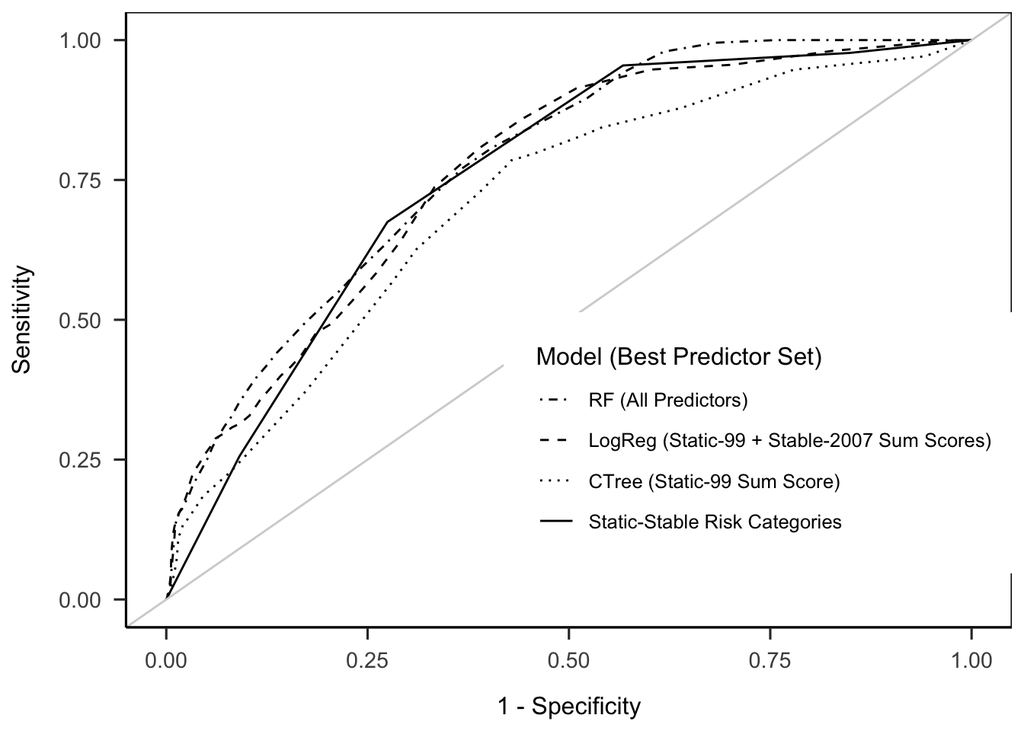

## Static sum + Stable sum | Static items + Stable items

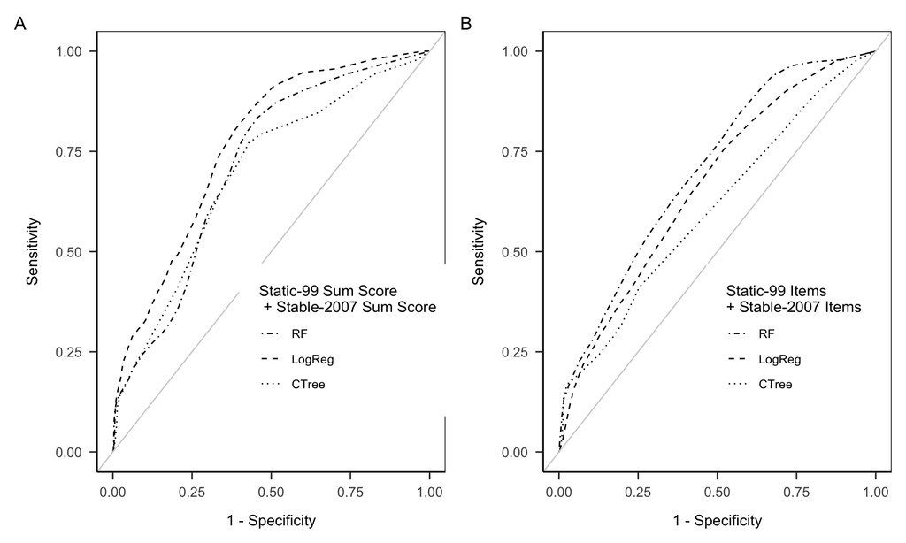

# Final Models and Interpretable Machine Learning

Interesting models to investigate further are:

- RF with **All predictors**
- RF with **Static sum + Stable sum**
- CTree with **Static sum + Stable sum**
- CTree with **Static items + Stable items**
- LogReg with **Static sum + Stable sum**

## Random Forest Permutation Feature Importance with All Predictors

This is kept for legacy/comparison reasons. We use the DALEX approach (next section), because it provides an interpretable metric (∆AUC).

|  | variable | importance |
| --- | --- | --- |
| 1 | vordelges | 0.0066 |
| 2 | StaSta_Kat_recalc | 0.0061 |
| 3 | STATIC_Sum_recalc | 0.006 |
| 4 | STATIC_Kat_recalc | 0.0041 |
| 5 | Kontrolle_Haftdauer_in_Tagen | 0.0036 |
| 6 | vordelgew | 0.0034 |
| 7 | vordelsex | 0.0031 |
| 8 | Stable_Sum | 0.0029 |
| 9 | Stable2007_Item_3 | 0.002 |
| 10 | Static99_Item_2 | 0.0015 |

[output cut: 2 more lines]

## Random Forest Permutation Feature Importance with All Predictors: ∆AUC with DALEX

[output not shown]

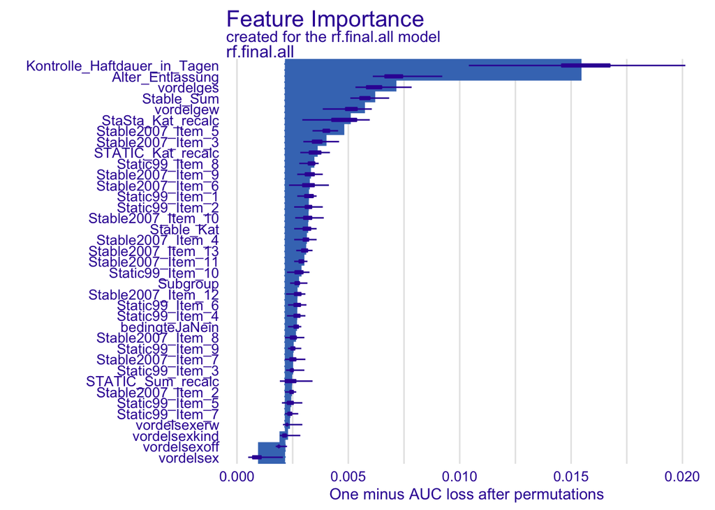

```
##                        variable mean_dropout_loss        label
## 1                  _full_model_      0.0021551724 rf.final.all
## 2                     vordelsex      0.0009473588 rf.final.all
## 3                  vordelsexoff      0.0019093910 rf.final.all
## 4                 vordelsexkind      0.0021790169 rf.final.all
## 5                  vordelsexerw      0.0022927366 rf.final.all
## 6               Static99_Item_7      0.0023789435 rf.final.all
## 7               Static99_Item_5      0.0024000367 rf.final.all
## 8             Stable2007_Item_2      0.0024376376 rf.final.all
## 9             STATIC_Sum_recalc      0.0024688188 rf.final.all
## 10              Static99_Item_3      0.0024798239 rf.final.all
## 11            Stable2007_Item_7      0.0025201761 rf.final.all
## 12              Static99_Item_9      0.0025229274 rf.final.all
## 13            Stable2007_Item_8      0.0025458547 rf.final.all
## 14               bedingteJaNein      0.0026504035 rf.final.all
```

[output cut: 25 more lines]

|  | variable | Delta_AUC |
| --- | --- | --- |
| 1 | Kontrolle_Haftdauer_in_Tagen | 0.0133 |
| 2 | Alter_Entlassung | 0.005 |
| 3 | vordelges | 0.0041 |
| 4 | Stable_Sum | 0.0036 |
| 5 | vordelgew | 0.003 |
| 6 | StaSta_Kat_recalc | 0.0027 |
| 7 | Stable2007_Item_5 | 0.0019 |
| 8 | Stable2007_Item_3 | 0.0015 |
| 9 | STATIC_Kat_recalc | 0.0013 |
| 10 | Static99_Item_8 | 0.0012 |

[output cut: 2 more lines]

```
##       auc
## 0.9978448
```

## Logistic Regression Coefficients with Static sum + Stable sum

```
##
## Call:
## stats::glm(formula = f, family = "binomial", data = getTaskData(.task,
##     .subset), weights = .weights, model = FALSE)
##
## Deviance Residuals:
##     Min       1Q   Median       3Q      Max
## -1.3281  -0.4578  -0.3100  -0.2059   2.7994
##
## Coefficients:
##                   Estimate Std. Error z value Pr(>|z|)
## (Intercept)       -5.19664    0.74255  -6.998 2.59e-12 ***
## STATIC_Sum_recalc  0.44329    0.07711   5.749 9.00e-09 ***
## Stable_Sum         0.07773    0.04622   1.682   0.0926 .
## ---
## Signif. codes:  0 '***' 0.001 '**' 0.01 '*' 0.05 '.' 0.1 ' ' 1
##
## (Dispersion parameter for binomial family taken to be 1)
##
##     Null deviance: 313.84  on 510  degrees of freedom
## Residual deviance: 269.11  on 508  degrees of freedom
## AIC: 275.11
##
## Number of Fisher Scoring iterations: 6
```

## Partial Dependence + Individual Conditional Expectation Plots for RF and LogReg with Static sum + Stable sum

Plots show the predicted values when one varies one predictor variable and keeps all other predictors constant. Each small line refers to a single observation for which the true values are used for the remaining predictors. The big yellow line is the average across all observations. Here we look at a prediction model with two predictors (Static sum + Stable sum) and see each variables contribution *in the context of the other*.

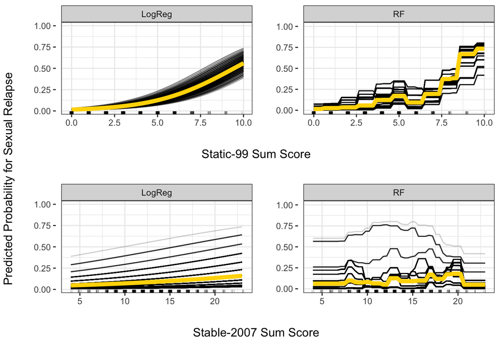

## Plot single trees

### Static sum + Stable sum

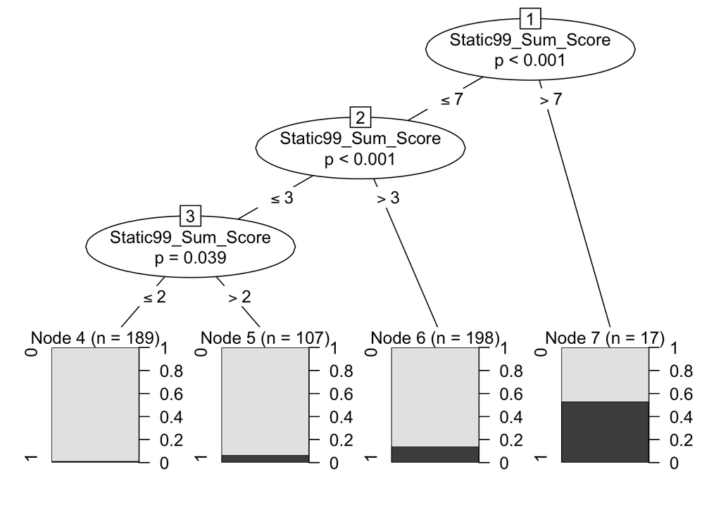

### Static items + Stable items

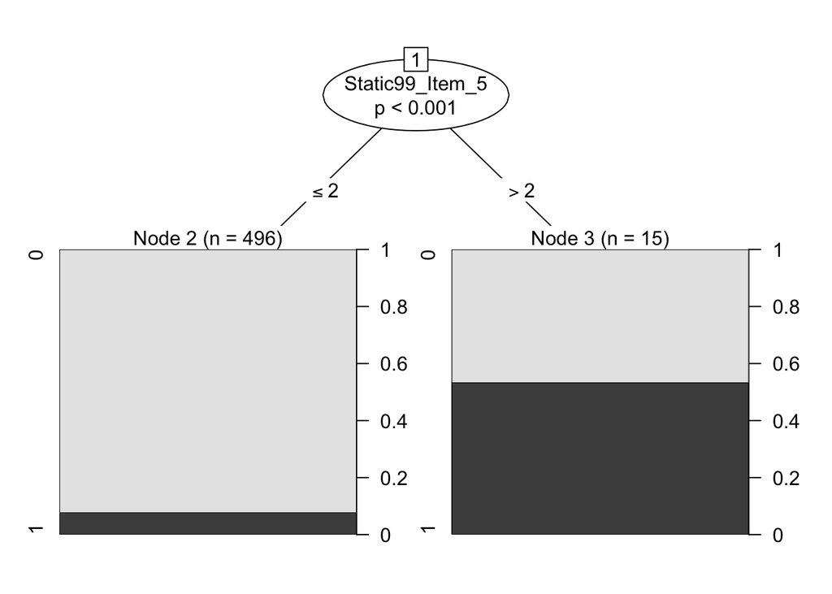

# Assess stability of each tree

### Stability of ctree with Static sum + Stable sum

```
##
## Call:
## ctree(formula = reformulate(termlabels = ".", response = "Relapse"),
##     data = getTaskData(task.SS.sum) %>% rename(Relapse = RF_Sex_FIX_5,
##         Static99_Sum_Score = STATIC_Sum_recalc, Stable2007_Sum_Score = Stable_Sum),
##     control = ctree_control(testtype = testtype, mincriterion = mincriterion,
##         minsplit = minsplit, minbucket = minbucket))
##
## Sampler:
## B = 1000
## Method = Stratified Bootstrap sampling with 100.0% data
##
## Variable selection overview:
##
##                      freq *  mean *
## Static99_Sum_Score   1.00 1 2.094 3
## Stable2007_Sum_Score 0.43 0 0.472 0
## (* = original tree)
```

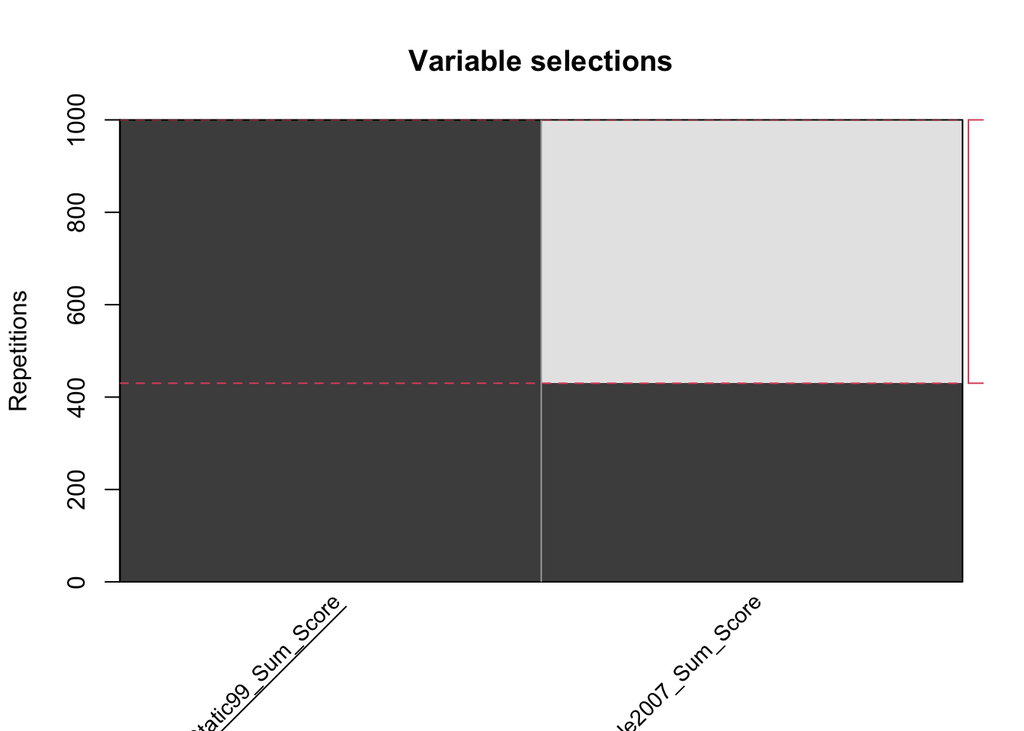

```
##  num [1:2] 430 1000
```

The same splitting variables were only selected in 56.9 percent of 1000 bootstrapped trees.

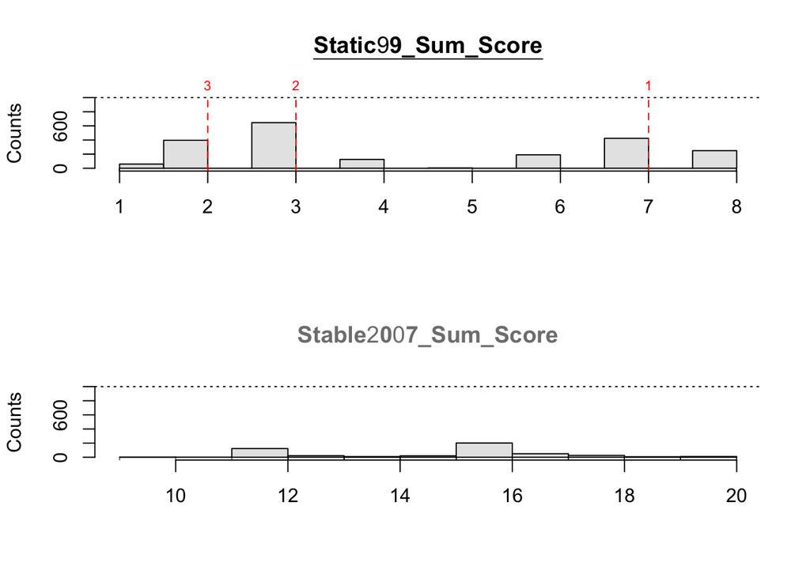

### Stability of ctree with Static items and Stable items

```
##
## Call:
## ctree(formula = reformulate(termlabels = ".", response = "Relapse"),
##     data = getTaskData(task.SS.items) %>% rename(Relapse = RF_Sex_FIX_5),
##     control = ctree_control(testtype = testtype, mincriterion = mincriterion,
##         minsplit = minsplit, minbucket = minbucket))
##
## Sampler:
## B = 1000
## Method = Stratified Bootstrap sampling with 100.0% data
##
## Variable selection overview:
##
##                     freq *  mean *
## Static99_Item_5    0.848 1 1.113 1
## Static99_Item_1    0.395 0 0.398 0
## Static99_Item_2    0.374 0 0.378 0
## Static99_Item_8    0.334 0 0.338 0
## Static99_Item_10   0.318 0 0.323 0
## Stable2007_Item_3  0.248 0 0.259 0
## Static99_Item_3    0.243 0 0.244 0
## Static99_Item_9    0.240 0 0.246 0
## Stable2007_Item_4  0.145 0 0.153 0
## Stable2007_Item_9  0.075 0 0.077 0
## Stable2007_Item_5  0.067 0 0.068 0
## Static99_Item_7    0.066 0 0.066 0
## Stable2007_Item_7  0.060 0 0.061 0
## Stable2007_Item_8  0.051 0 0.051 0
## Stable2007_Item_6  0.044 0 0.046 0
## Stable2007_Item_11 0.039 0 0.039 0
## Stable2007_Item_13 0.036 0 0.036 0
## Stable2007_Item_10 0.029 0 0.030 0
## Static99_Item_6    0.028 0 0.028 0
## Stable2007_Item_12 0.021 0 0.021 0
## Stable2007_Item_2  0.017 0 0.017 0
## Static99_Item_4    0.009 0 0.009 0
## (* = original tree)
```

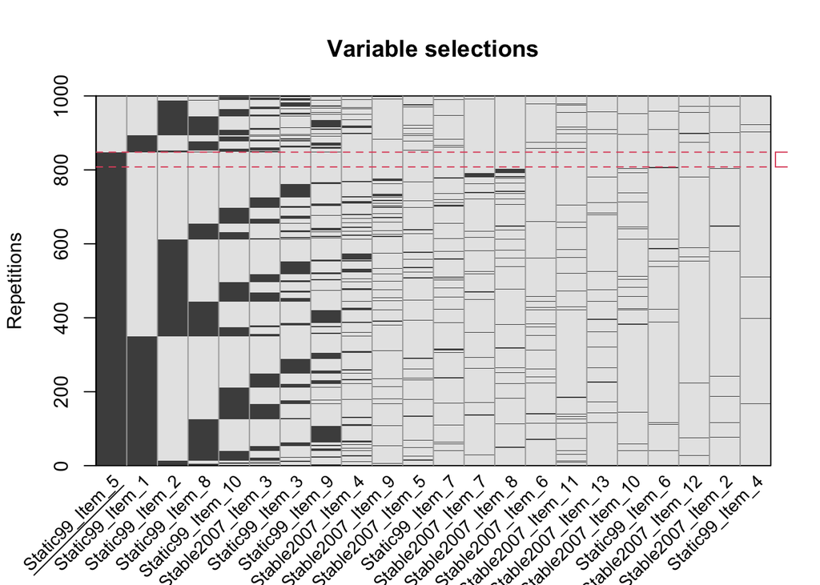

```
##  num [1:2] 808 848
```

The same splitting variables were only selected in 3.9 percent of 1000 bootstrapped trees.

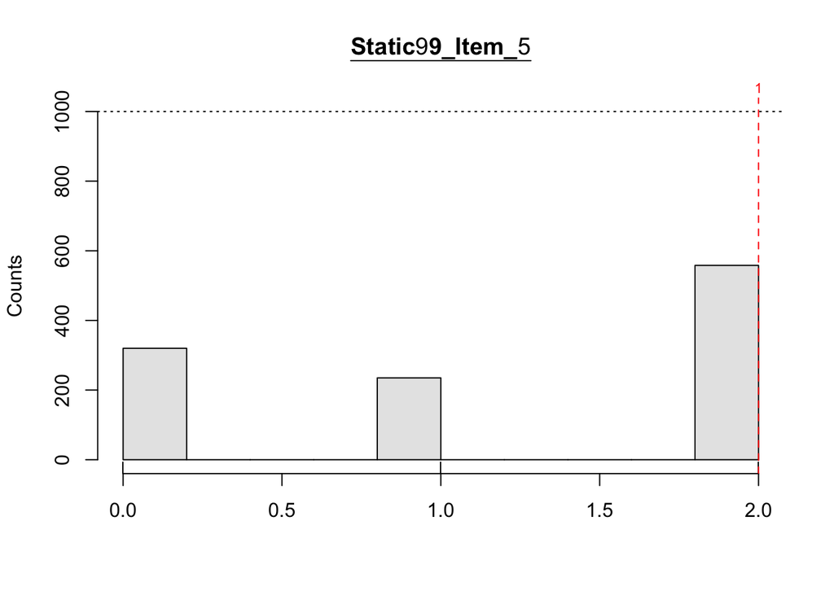